# Kuis_DS-B

Torangto Situngkir_123180122

##Intro ##Baca Petunjuk Terlebih Dahulu!

0. Cuci tangan dengan sabun hingga benar-benar bersih dengan durasi mencuci tangan kurang lebih 20 detik
1. Kerjakan soal-soal yang ada! Jangan lupa tulis NAMA dan NIM pada author!
2. Kuis terdiri dari 2 bagian yaitu bagian pertama dan bagian kedua
3. Jawablah dengan mengisi chunk dibawah soal!
4. Durasi pengerjaan sesuai selama 3 hari, dikumpulkan maksimal Rabu, 9 Desember 2020
5. No toleransi pengumpulan telat. Ingat, telat kemungkinan terburuk ga ada nilai kuis!
6. Misal soal rancu bisa menghubungi asisten terkait
7. Export hasil pekerjaan dalam format PDF/Word & sesuaikan nama file sesuai NIM masing-masing.

##BAGIAN PERTAMA

1. Load library apa saja yang kira-kira digunakan! Lalu gunakan data ‘us_contagious_diseases’! **point 1**

```r
  library(dslabs)
  library(tidyverse)
  data("us_contagious_diseases")
```

2. Tampilkan semua nama kolom pada data frame yang ada! **point 5**

```r
  names(us_contagious_diseases)
```

```
## [1] "disease"         "state"           "year"            "weeks_reporting"
## [5] "count"           "population"
```

3. Tampilkan tipe data pada kolom penyakit! **point 5**

```r
  class(us_contagious_diseases$disease)
```

```
## [1] "factor"
```

4. Tampilkan 10 data penyakit polio teratas diurutkan berdasarkan populasi dan terjadi pada antara tahun 1965 dan 1955! **point 11**

```r
  us_contagious_diseases %>%
  filter(year>1955 & year<1965,disease=="Polio") %>%
  arrange(desc(population)) %>%
  head(n=10)
```

```
##    disease      state year weeks_reporting count population
## 1    Polio California 1964              25     2   17581336
## 2    Polio   New York 1964              39    10   17572556
## 3    Polio   New York 1963              48    12   17387034
## 4    Polio   New York 1962              48    88   17190958
## 5    Polio California 1963              52    19   17135662
## 6    Polio   New York 1961              48   256   16988157
## 7    Polio   New York 1960              52   280   16782304
## 8    Polio California 1962              50    88   16676046
## 9    Polio   New York 1959              39   353   16576443
## 10   Polio   New York 1958              50   292   16371622
```

5. Klasifikasikan data tersebut berdasarkan jumlah kasusnya dengan kondisi : -jumlah kasus kurang dari 1000 dikategorikan sebagai “Biasa” -jumlah kasus lebih dari 2000 dikategorikan sebagai “Azab -jumlah kasus antara kedua kondisi diatas dikategorikan sebagai”Cobaan"

NB : jika dirasa jumlah data hasilnya terlalu banyak boleh menggunakan fungsi top_n() atau head()**point 10**

```r
  klasifikasi = ""
  for(i in 1:nrow(us_contagious_diseases)){
    if(us_contagious_diseases$count[i] < 1000) {
      klasifikasi[i] <- "Biasa"
    }
    else if(us_contagious_diseases$count[i] > 2000) {
      klasifikasi[i] <- "Azab"
    }
    else{
      klasifikasi[i] <- "Cobaan"
    }
  }
  head(klasifikasi,n=300)
```

```
##   [1] "Biasa"  "Biasa"  "Biasa"  "Biasa"  "Biasa"  "Biasa"  "Biasa"  "Biasa"
##   [9] "Biasa"  "Biasa"  "Biasa"  "Biasa"  "Biasa"  "Biasa"  "Biasa"  "Biasa"
##  [17] "Biasa"  "Biasa"  "Biasa"  "Biasa"  "Biasa"  "Biasa"  "Biasa"  "Biasa"
##  [25] "Biasa"  "Biasa"  "Biasa"  "Biasa"  "Biasa"  "Biasa"  "Biasa"  "Biasa"
##  [33] "Biasa"  "Biasa"  "Biasa"  "Biasa"  "Biasa"  "Biasa"  "Biasa"  "Biasa"
##  [41] "Biasa"  "Biasa"  "Biasa"  "Biasa"  "Biasa"  "Biasa"  "Biasa"  "Biasa"
##  [49] "Biasa"  "Biasa"  "Biasa"  "Biasa"  "Biasa"  "Biasa"  "Biasa"  "Biasa"
##  [57] "Cobaan" "Biasa"  "Biasa"  "Biasa"  "Biasa"  "Biasa"  "Biasa"  "Biasa"
##  [65] "Biasa"  "Biasa"  "Biasa"  "Biasa"  "Biasa"  "Biasa"  "Biasa"  "Biasa"
##  [73] "Biasa"  "Biasa"  "Biasa"  "Biasa"  "Biasa"  "Biasa"  "Biasa"  "Biasa"
##  [81] "Biasa"  "Biasa"  "Biasa"  "Biasa"  "Biasa"  "Biasa"  "Biasa"  "Biasa"
##  [89] "Biasa"  "Biasa"  "Biasa"  "Biasa"  "Biasa"  "Biasa"  "Biasa"  "Biasa"
##  [97] "Biasa"  "Biasa"  "Biasa"  "Biasa"  "Biasa"  "Biasa"  "Biasa"  "Biasa"
## [105] "Cobaan" "Cobaan" "Biasa"  "Biasa"  "Biasa"  "Biasa"  "Biasa"  "Cobaan"
## [113] "Cobaan" "Cobaan" "Biasa"  "Azab"   "Cobaan" "Biasa"  "Biasa"  "Biasa"
```

[output cut: 23 more lines]

6. Tambahkan variabel baru berisi data ‘us_contagious_diseases’ dengan tambahan kolom baru dengan nama “category” yang isinya merupakan implementasi nomor 5 dan kolom “rate” yang isinya merupakan hasil bagi jumlah kasus dengan populasi dikalikan 100000! **point 10**

```r
  newData <- us_contagious_diseases %>%
  mutate(
    Category = klasifikasi,
    Rate = count/population*10^5
  )
  head(newData,n=10)
```

```
##        disease   state year weeks_reporting count population Category      Rate
## 1  Hepatitis A Alabama 1966              50   321    3345787    Biasa  9.594155
## 2  Hepatitis A Alabama 1967              49   291    3364130    Biasa  8.650082
## 3  Hepatitis A Alabama 1968              52   314    3386068    Biasa  9.273293
## 4  Hepatitis A Alabama 1969              49   380    3412450    Biasa 11.135694
## 5  Hepatitis A Alabama 1970              51   413    3444165    Biasa 11.991295
## 6  Hepatitis A Alabama 1971              51   378    3481798    Biasa 10.856460
## 7  Hepatitis A Alabama 1972              45   342    3524543    Biasa  9.703386
## 8  Hepatitis A Alabama 1973              45   467    3571209    Biasa 13.076804
## 9  Hepatitis A Alabama 1974              45   244    3620548    Biasa  6.739311
## 10 Hepatitis A Alabama 1975              46   286    3671246    Biasa  7.790271
```

7. Tampilkan kesimpulan pada data nomor 6 dikelompokkan berdasarkan negara bagian yang isinya nama negara bagian dan rata-rata rate per negara bagian! **point 8**

```r
  kesimpulan <- newData %>%
  group_by(state) %>%
  summarize(Rata_Rata=mean(Rate))
  kesimpulan
```

```
## # A tibble: 51 x 2
##    state                Rata_Rata
##    <fct>                    <dbl>
##  1 Alabama                   27.3
##  2 Alaska                    NA
##  3 Arizona                   77.5
##  4 Arkansas                  29.4
##  5 California                58.6
##  6 Colorado                  73.2
##  7 Connecticut               72.1
##  8 Delaware                  44.0
##  9 District Of Columbia      36.8
## 10 Florida                   24.4
## # ... with 41 more rows
```

8. Lakukan visualisasi pada hasil nomor 7!(Bebas menggunakan plot, boxplot, hist, ggplot2 dsb) **point 5**

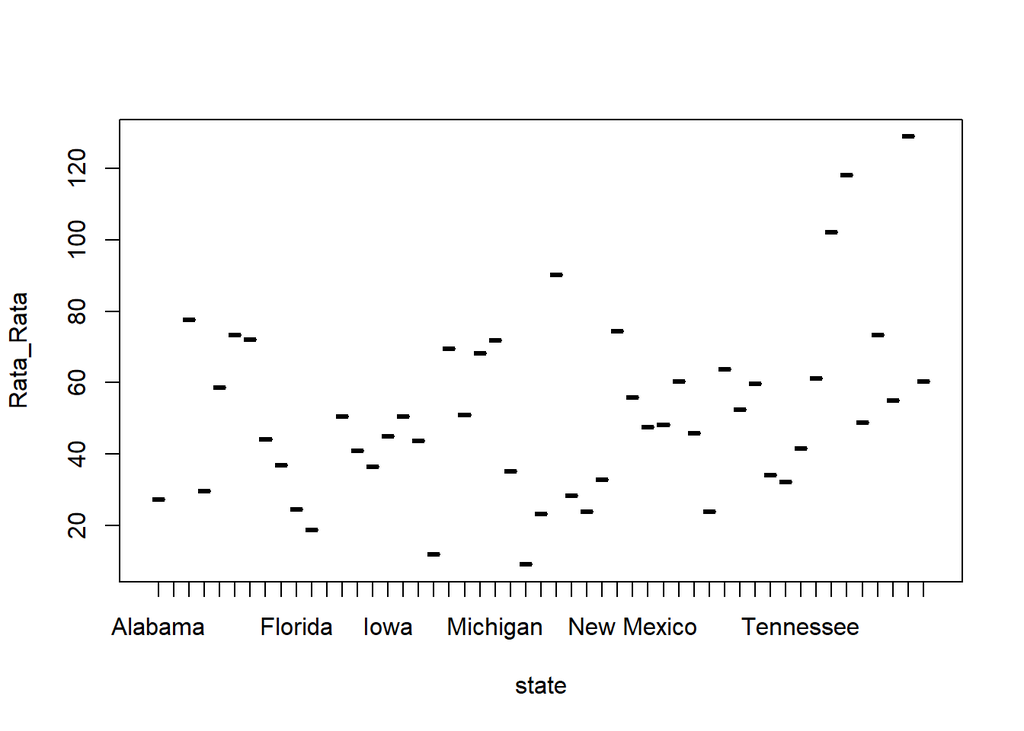

```r
  plot(kesimpulan)
```

##BAGIAN KEDUA

1. Load library tambahan untuk import file! **point 2**

```r
  library(readr)
  library (ggplot2)
  Covid19_Asean <- read_csv("Covid19_Asean.csv")
```

2. Tampilkan informasi rinci tentang struktur dataset yang digunakan! **point 5**

```r
  str(Covid19_Asean)
```

```
## tibble [10 x 5] (S3: spec_tbl_df/tbl_df/tbl/data.frame)
##  $ Country    : chr [1:10] "Indonesia" "Malaysia" "Myanmar" "Vietnam" ...
##  $ CountryCode: chr [1:10] "ID" "MY" "MM" "VN" ...
##  $ Confirmed  : num [1:10] 2738 3963 22 249 2258 ...
##  $ Recovered  : num [1:10] 204 1321 0 123 888 ...
##  $ Deaths     : num [1:10] 221 63 1 0 27 0 0 6 177 0
##  - attr(*, "spec")=
##   .. cols(
##   ..   Country = col_character(),
##   ..   CountryCode = col_character(),
##   ..   Confirmed = col_double(),
##   ..   Recovered = col_double(),
##   ..   Deaths = col_double()
##   .. )
```

3. Tampilkan nama Negara dengan jumlah Penderita Covid-19 yang Terkonfirmasi dari paling banyak ke paling sedikit! **point 8**

```r
  Covid19_Asean %>%
  arrange(desc(Confirmed))
```

```
## # A tibble: 10 x 5
##    Country     CountryCode Confirmed Recovered Deaths
##    <chr>       <chr>           <dbl>     <dbl>  <dbl>
##  1 Malaysia    MY               3963      1321     63
##  2 Filipina    PH               3764        84    177
##  3 Indonesia   ID               2738       204    221
##  4 Thailand    TH               2258       888     27
##  5 Singapura   SG               1481       377      6
##  6 Vietnam     VN                249       123      0
##  7 Kamboja     KB                115        58      0
##  8 Myanmar     MM                 22         0      1
##  9 Laos        LA                 14         0      0
## 10 Timor Leste TL                  1         0      0
```

4. Buat kolom baru bernama RateDeaths yang berisi rasio korban Covid-19 yang meninggal dengan yang terkonfirmasi! **point 11**

```r
  Covid19_Asean = mutate(Covid19_Asean,RateDeaths = Deaths / Confirmed)
```

5. Negara mana yang memiliki rasio kematian Covid-19 tertinggi dan terendah? Tampilkan nama negaranya. **point 11**

```r
  print("Tertinggi")
```

```
## [1] "Tertinggi"
```

```r
  filter(Covid19_Asean,RateDeaths == max(Covid19_Asean$RateDeaths))
```

```
## # A tibble: 1 x 6
##   Country   CountryCode Confirmed Recovered Deaths RateDeaths
##   <chr>     <chr>           <dbl>     <dbl>  <dbl>      <dbl>
## 1 Indonesia ID               2738       204    221     0.0807
```

```r
  print("Terendah")
```

```
## [1] "Terendah"
```

```r
  filter(Covid19_Asean,RateDeaths == min(Covid19_Asean$RateDeaths))
```

```
## # A tibble: 4 x 6
##   Country     CountryCode Confirmed Recovered Deaths RateDeaths
##   <chr>       <chr>           <dbl>     <dbl>  <dbl>      <dbl>
## 1 Vietnam     VN                249       123      0          0
## 2 Laos        LA                 14         0      0          0
## 3 Kamboja     KB                115        58      0          0
## 4 Timor Leste TL                  1         0      0          0
```

6. Tampilkan grafik plot antara penderita yang sembuh degan penderita yang terkonfirmasi Covid-19! **point 8**

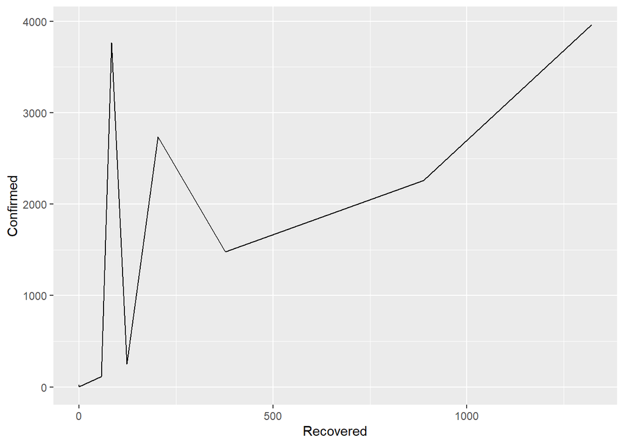

```r
  Covid19_Asean %>%
  ggplot(aes(x = Recovered, y = Confirmed)) +
  geom_line()
```